# Investigating the Global Housing Crisis

## Final Project

Chiara Adjoh-Davoh

ID: 004002088

## Data Understanding and Cleaning

### Loading Data

To begin, we start by loading into and examining the raw data from the data file. We first import all of our libraries, including the ones we will use later to visualize the data. Then we display the first few rows to assess a glimpse of our data and then use the info() function to check for null values and see what data types are present in each column. The shape() function lets us see how many rows and columns there are and the describe() function gives some key statistics regarding each numerical column. It also helps us find nonsensical values, like negative mortgage rates, by looking at our minimum values. Since there are none, we can move on to cleaning up our data.

```python
import pandas as pd
import numpy as np
import seaborn as sns
import matplotlib.pyplot as plt
import plotly.express as px
# importing my libraries

df = pd.read_csv("global_housing_market.csv") # reading the csv file into the dataframe

df.head() # show first few rows
```

|  | Country | Year | House Price Index | Rent Index | Affordability Ratio | Mortgage Rate (%) | Inflation Rate (%) | GDP Growth (%) | Population Growth (%) | Urbanization Rate (%) | Construction Index |
| --- | --- | --- | --- | --- | --- | --- | --- | --- | --- | --- | --- |
| 0 | USA | 2015 | 117.454012 | 116.550001 | 9.587945 | 4.493292 | 1.514121 | -0.752044 | -0.796707 | 85.985284 | 118.089201 |
| 1 | USA | 2016 | 150.807258 | 51.440915 | 11.729189 | 5.662213 | 1.880204 | -0.545400 | -0.358084 | 69.127267 | 111.980515 |
| 2 | USA | 2017 | 123.194502 | 70.386040 | 8.506676 | 2.197469 | 2.398940 | 0.930895 | 0.596245 | 83.555279 | 85.973903 |
| 3 | USA | 2018 | 131.423444 | 91.469020 | 3.418054 | 4.537724 | 1.608407 | -1.479587 | 2.321099 | 88.968961 | 134.671788 |
| 4 | USA | 2019 | 110.461377 | 56.837048 | 9.158097 | 3.700762 | 1.293249 | 1.961415 | -0.879640 | 87.279612 | 90.702399 |

```python
df.info() # show important info about the data frame
```

```
<class 'pandas.core.frame.DataFrame'>
RangeIndex: 200 entries, 0 to 199
Data columns (total 11 columns):
 #   Column                 Non-Null Count  Dtype
---  ------                 --------------  -----
 0   Country                200 non-null    object
 1   Year                   200 non-null    int64
 2   House Price Index      200 non-null    float64
 3   Rent Index             200 non-null    float64
 4   Affordability Ratio    200 non-null    float64
 5   Mortgage Rate (%)      200 non-null    float64
 6   Inflation Rate (%)     200 non-null    float64
 7   GDP Growth (%)         200 non-null    float64
 8   Population Growth (%)  200 non-null    float64
 9   Urbanization Rate (%)  200 non-null    float64
 10  Construction Index     200 non-null    float64
dtypes: float64(9), int64(1), object(1)
memory usage: 17.3+ KB
```

```python
np.shape(df) # display shape of the data frame
```

```
(200, 11)
```

```python
df.describe() # shows key statistics about each column
```

|  | Year | House Price Index | Rent Index | Affordability Ratio | Mortgage Rate (%) | Inflation Rate (%) | GDP Growth (%) | Population Growth (%) | Urbanization Rate (%) | Construction Index |
| --- | --- | --- | --- | --- | --- | --- | --- | --- | --- | --- |
| count | 200.000000 | 200.000000 | 200.000000 | 200.000000 | 200.000000 | 200.000000 | 200.000000 | 200.000000 | 200.000000 | 200.000000 |
| mean | 2019.500000 | 130.381022 | 83.048370 | 7.237768 | 4.150621 | 3.649756 | 2.133722 | 0.722806 | 74.769891 | 111.204257 |
| std | 2.879489 | 28.752229 | 21.439858 | 2.576085 | 1.380222 | 1.881938 | 2.413270 | 1.035691 | 8.734246 | 24.309473 |
| min | 2015.000000 | 80.552212 | 50.354311 | 3.041688 | 1.537814 | 0.532110 | -1.921833 | -0.961391 | 60.172760 | 70.968678 |
| 25% | 2017.000000 | 104.142562 | 60.466671 | 5.034207 | 3.045278 | 1.939199 | -0.095628 | -0.183320 | 66.923842 | 90.182198 |
| 50% | 2019.500000 | 129.193653 | 83.721711 | 7.375697 | 4.329643 | 3.664625 | 2.307548 | 0.722372 | 75.100060 | 110.593807 |
| 75% | 2022.000000 | 157.127098 | 100.604665 | 9.276196 | 5.217706 | 5.261720 | 4.272776 | 1.621317 | 82.677430 | 133.780445 |
| max | 2024.000000 | 179.971767 | 119.855388 | 11.879671 | 6.485623 | 6.912349 | 5.958931 | 2.497948 | 89.788944 | 149.735748 |

### Drop Duplicates

To begin cleaning up our data, let's drop all duplicate rows and then check our shape to see if its changed. There's still 200 rows so it can be concluded that there were no duplicates.

```python
df = df.drop_duplicates() # drops duplicate rows
np.shape(df) # checks the shape again
```

```
(200, 11)
```

### Renaming and Dropping Columns

Next, let's rename some of the columns to create clarity of their purpose. "Affordability Ratio" becomes "Price to Income Ratio" to more accurately describe what the column is calculating. Additionally, "Urbanization Rate (%)" becomes "Urbanization (%)" becasuse when reading the documentation for the dataset, the number is not a rate of urbanization but rather a simple percentage of the population that lives in an urban area. Next, I dropped the "Construction Index" column as I couldn't find a purpose for it and its relevance wasn't clear.

```python
df.rename(columns={'Affordability Ratio' : 'Price to Income Ratio', 'Urbanization Rate (%)' : 'Urbanization (%)'}, inplace=True) # changes the name of the columns
df.pop('Construction Index') # drops the "Construction Index" column

df.head()
```

|  | Country | Year | House Price Index | Rent Index | Price to Income Ratio | Mortgage Rate (%) | Inflation Rate (%) | GDP Growth (%) | Population Growth (%) | Urbanization (%) |
| --- | --- | --- | --- | --- | --- | --- | --- | --- | --- | --- |
| 0 | USA | 2015 | 117.454012 | 116.550001 | 9.587945 | 4.493292 | 1.514121 | -0.752044 | -0.796707 | 85.985284 |
| 1 | USA | 2016 | 150.807258 | 51.440915 | 11.729189 | 5.662213 | 1.880204 | -0.545400 | -0.358084 | 69.127267 |
| 2 | USA | 2017 | 123.194502 | 70.386040 | 8.506676 | 2.197469 | 2.398940 | 0.930895 | 0.596245 | 83.555279 |
| 3 | USA | 2018 | 131.423444 | 91.469020 | 3.418054 | 4.537724 | 1.608407 | -1.479587 | 2.321099 | 88.968961 |
| 4 | USA | 2019 | 110.461377 | 56.837048 | 9.158097 | 3.700762 | 1.293249 | 1.961415 | -0.879640 | 87.279612 |

```python
np.shape(df) # used to check the shape after dropping the construction index column
```

```
(200, 10)
```

### Adding New Columns

Next, we're going to add some variables to make our analysis more dynamic. A new "Region" variable categorizes the data based on its country, for example, Germany -> Europe. Another variable called "Post Pandemic" categorizes the data as either pre or post the COVID pandemic, with a 0 for pre- and a 1 for post-pandemic. Lastly, "Rent to Income Ratio" calculates the rent to income ratio using the variable "Price to Income Ratio" since the dataset does not directly provide information about the average income at each time period.

```python
def region(country): # takes the string and sorts it using the if else, returning the region. this is not feasible for larger sets but it worked fine for this set of only 14 countries
    if country == "UK" or country == "Germany" or country == "France" or country == "Russia" or country == "Italy" or country == "Spain" or country == "Netherlands" or country == "Sweden" or country == "Switzerland":
        return "Europe"
    elif country == "South Africa" or country == "UAE":
        return "Africa & Middle East"
    elif country == "Australia":
        return "Oceania"
    elif country == "Mexico" or country == "Brazil":
        return "Central & South America"
    elif country == "Canada" or country == "USA":
        return "North America"
    elif country == "India" or country == "Japan" or country == "South Korea" or country == "China":
        return "Asia"
df['Region'] = df['Country'].apply(region)

def preorpost(year): # returns an integer based on if the date is pre, post or during the pandemic
    if year >= 2020:
        return 1
    elif year < 2020:
        return 0
df['Post Pandemic'] = df['Year'].apply(preorpost)

df['Rent to Income Ratio'] = df['Price to Income Ratio'] / df['House Price Index'] * df['Rent Index']
# uses the price to income ratio, house price index and rent index in order to calculate the rent to income ratio since the data set does not directly provide income information

df.info() # used to check the null count and variable type for the new columns
```

```
<class 'pandas.core.frame.DataFrame'>
RangeIndex: 200 entries, 0 to 199
Data columns (total 13 columns):
 #   Column                 Non-Null Count  Dtype
---  ------                 --------------  -----
 0   Country                200 non-null    object
 1   Year                   200 non-null    int64
 2   House Price Index      200 non-null    float64
 3   Rent Index             200 non-null    float64
 4   Price to Income Ratio  200 non-null    float64
 5   Mortgage Rate (%)      200 non-null    float64
 6   Inflation Rate (%)     200 non-null    float64
 7   GDP Growth (%)         200 non-null    float64
 8   Population Growth (%)  200 non-null    float64
 9   Urbanization (%)       200 non-null    float64
 10  Region                 200 non-null    object
 11  Post Pandemic          200 non-null    int64
 12  Rent to Income Ratio   200 non-null    float64
dtypes: float64(9), int64(2), object(2)
memory usage: 20.4+ KB
```

```python
display(df[:10]) # displays first 10 entries, to make sure our new columns' values make sense.
```

|  | Country | Year | House Price Index | Rent Index | Price to Income Ratio | Mortgage Rate (%) | Inflation Rate (%) | GDP Growth (%) | Population Growth (%) | Urbanization (%) | Region | Post Pandemic | Rent to Income Ratio |
| --- | --- | --- | --- | --- | --- | --- | --- | --- | --- | --- | --- | --- | --- |
| 0 | USA | 2015 | 117.454012 | 116.550001 | 9.587945 | 4.493292 | 1.514121 | -0.752044 | -0.796707 | 85.985284 | North America | 0 | 9.514150 |
| 1 | USA | 2016 | 150.807258 | 51.440915 | 11.729189 | 5.662213 | 1.880204 | -0.545400 | -0.358084 | 69.127267 | North America | 0 | 4.000870 |
| 2 | USA | 2017 | 123.194502 | 70.386040 | 8.506676 | 2.197469 | 2.398940 | 0.930895 | 0.596245 | 83.555279 | North America | 0 | 4.860211 |
| 3 | USA | 2018 | 131.423444 | 91.469020 | 3.418054 | 4.537724 | 1.608407 | -1.479587 | 2.321099 | 88.968961 | North America | 0 | 2.378921 |
| 4 | USA | 2019 | 110.461377 | 56.837048 | 9.158097 | 3.700762 | 1.293249 | 1.961415 | -0.879640 | 87.279612 | North America | 0 | 4.712228 |
| 5 | USA | 2020 | 146.252228 | 71.819775 | 7.680612 | 4.233551 | 1.701554 | 5.756677 | 1.712965 | 88.184968 | North America | 1 | 3.771702 |
| 6 | USA | 2021 | 139.789998 | 114.531196 | 3.796433 | 2.479914 | 0.793977 | 0.602643 | 0.360371 | 68.140471 | North America | 1 | 3.110451 |
| 7 | USA | 2022 | 115.675333 | 69.665416 | 7.884265 | 2.204621 | 5.714280 | -1.403595 | 2.454104 | 83.167343 | North America | 1 | 4.748295 |
| 8 | USA | 2023 | 80.552212 | 107.082300 | 9.361716 | 5.145036 | 5.513257 | -1.407643 | 0.254630 | 63.476072 | North America | 1 | 12.445023 |
| 9 | USA | 2024 | 142.329813 | 73.162862 | 3.572025 | 3.054912 | 2.613692 | 3.836849 | 1.231451 | 86.616382 | North America | 1 | 1.836155 |

## Exploratory Data Analysis

### Key Statistics

Let's start by looking at the statistics for all of our numerical columns using the describe() function. These observations are touched on more in the full report but some interesting takeaways include:

```python
df.describe() # key statistics about our columns
```

|  | Year | House Price Index | Rent Index | Price to Income Ratio | Mortgage Rate (%) | Inflation Rate (%) | GDP Growth (%) | Population Growth (%) | Urbanization (%) | Post Pandemic | Rent to Income Ratio |
| --- | --- | --- | --- | --- | --- | --- | --- | --- | --- | --- | --- |
| count | 200.000000 | 200.000000 | 200.000000 | 200.000000 | 200.000000 | 200.000000 | 200.000000 | 200.000000 | 200.000000 | 200.000000 | 200.000000 |
| mean | 2019.500000 | 130.381022 | 83.048370 | 7.237768 | 4.150621 | 3.649756 | 2.133722 | 0.722806 | 74.769891 | 0.500000 | 4.853765 |
| std | 2.879489 | 28.752229 | 21.439858 | 2.576085 | 1.380222 | 1.881938 | 2.413270 | 1.035691 | 8.734246 | 0.501255 | 2.472400 |
| min | 2015.000000 | 80.552212 | 50.354311 | 3.041688 | 1.537814 | 0.532110 | -1.921833 | -0.961391 | 60.172760 | 0.000000 | 1.033047 |
| 25% | 2017.000000 | 104.142562 | 60.466671 | 5.034207 | 3.045278 | 1.939199 | -0.095628 | -0.183320 | 66.923842 | 0.000000 | 2.881749 |
| 50% | 2019.500000 | 129.193653 | 83.721711 | 7.375697 | 4.329643 | 3.664625 | 2.307548 | 0.722372 | 75.100060 | 0.500000 | 4.621544 |
| 75% | 2022.000000 | 157.127098 | 100.604665 | 9.276196 | 5.217706 | 5.261720 | 4.272776 | 1.621317 | 82.677430 | 1.000000 | 6.059092 |
| max | 2024.000000 | 179.971767 | 119.855388 | 11.879671 | 6.485623 | 6.912349 | 5.958931 | 2.497948 | 89.788944 | 1.000000 | 13.707510 |

### Groupby Stats

Next, let's look at how grouping by country and region produce interesting results. First, simply counting the values for each country reveal an even spread of data for every country chosen, with all representing 10 data points. However, when we take a look at the value counts by region, there's 9 European countries represented, which is almost half. This reveals a European slant to the overall data.

If we now look at the affordability for the regions in general, Africa & the Middle East had the highest Price & Rent to Income ratios while Oceania & South America were the least. While we might generally attribute a high Price & Rent to Income ratio as meaning that housing is more affordable for most people, it can also be a sign of very large wealth disparities. Small, wealthy classes in these places drive up the housing prices while the average income remains low.

```python
display(df['Country'].value_counts())
display(df['Region'].value_counts()) # value counts for country and region
```

```
Country
USA             10
Canada          10
Switzerland     10
Sweden          10
Netherlands     10
Russia          10
South Africa    10
Mexico          10
South Korea     10
Brazil          10
Japan           10
China           10
India           10
Australia       10
Spain           10
Italy           10
France          10
Germany         10
UK              10
UAE             10
Name: count, dtype: int64
```

```
Region
Europe                     90
Asia                       40
North America              20
Central & South America    20
Africa & Middle East       20
Oceania                    10
Name: count, dtype: int64
```

```python
display(df.groupby('Region')['Urbanization (%)'].median()) # chose median instead of mean because outliers can have a greater effect when we choose mean
display(df.groupby('Region')['Rent to Income Ratio'].mean())
display(df.groupby('Region')['Price to Income Ratio'].mean())
```

```
Region
Africa & Middle East       75.407007
Asia                       70.322450
Central & South America    75.263705
Europe                     76.694763
North America              76.322122
Oceania                    70.018604
Name: Urbanization (%), dtype: float64
```

```
Region
Africa & Middle East       6.193553
Asia                       4.669853
Central & South America    4.123802
Europe                     4.846678
North America              5.242032
Oceania                    3.657008
Name: Rent to Income Ratio, dtype: float64
```

```
Region
Africa & Middle East       8.010146
Asia                       6.957661
Central & South America    6.111098
Europe                     7.573171
North America              7.081850
Oceania                    6.359994
Name: Price to Income Ratio, dtype: float64
```

## Data Visualization and Interpretation

### Heatmap

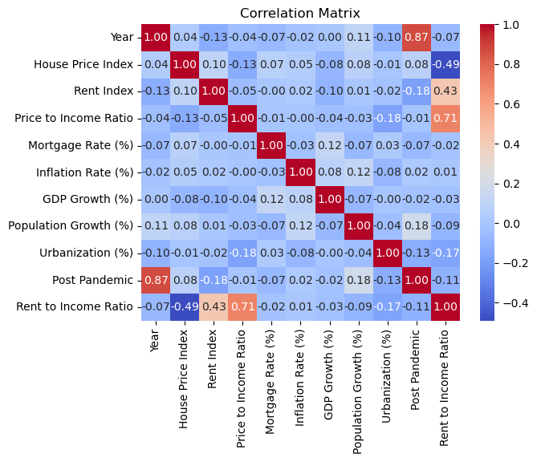

```python
df_corr = df.corr(numeric_only=True) # creates a correlation matrix for our numeric columns
sns.heatmap(df_corr, annot =True, cmap = "coolwarm", fmt=".2f") # turns on annoations, make the color scheme cool-warm, and limits to 2 decimal places
plt.title("Correlation Matrix")
plt.show()
```

### Average House Price Index

These graphs take a look at the average house price index by both country and by region. When looking at country, the top 5 countries are Italy, France, Netherland, Brazil and Switzerland. 4/5 of those countries are European. However, when we look by region, the top region is actually Central & South America. Europe isn't even 2nd, its the 3rd highest. I believe this is caused by the overall European skew of the data. There are way more European entries in the data than other regions, so when grouped as a region, their normals tend to normalize towards less extreme numbers because there's more data to aggregate. Other countries, however, tend to have more extreme means because they may only have one or two countries representing them.

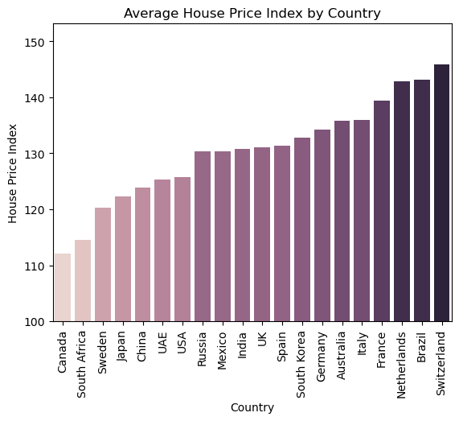

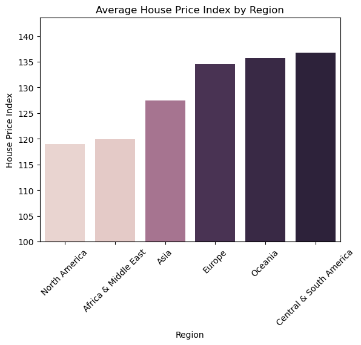

```python
df_cou = df.groupby("Country").agg({
    "House Price Index" : "mean",
    "Rent Index" : "mean",
    "Price to Income Ratio" : "mean",
    "Rent to Income Ratio" : "mean"}) # aggregates the shown columns by country for later use in visualizations

sns.barplot(data=df_cou.sort_values("House Price Index"), x="Country", y="House Price Index", hue="House Price Index", legend=False)
plt.xticks(rotation=90) # rotates the names of the countries to make it readable
plt.ylim(100) # limits the y-value to make the differences more obvious
plt.title("Average House Price Index by Country")
plt.show()
# barplot for the house price index by country

df_reg = df.groupby("Region").agg({
    "House Price Index" : "mean",
    "Rent Index" : "mean",
    "Price to Income Ratio" : "mean",
    "Rent to Income Ratio" : "mean"}) # aggregates the shown columns by region for later use

sns.barplot(data=df_reg.sort_values("House Price Index"), x="Region", y="House Price Index", hue="House Price Index", legend=False)
plt.xticks(rotation=45)
plt.ylim(100)
plt.title("Average House Price Index by Region")
plt.show()
# barplot for the house price index by region
```

### Mortgage Rate Distribution

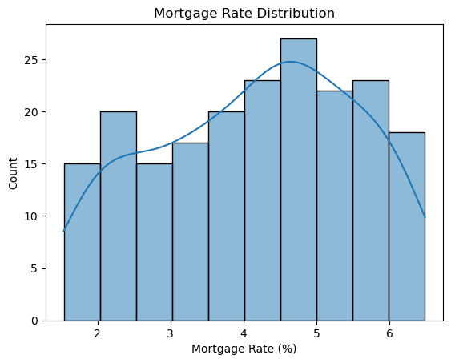

```python
sns.histplot(df, x='Mortgage Rate (%)', binwidth=0.5, kde=True) # creates a histogram with a bin width of 0.5 as well as a line showing the general trend
plt.title("Mortgage Rate Distribution")
plt.show()
```

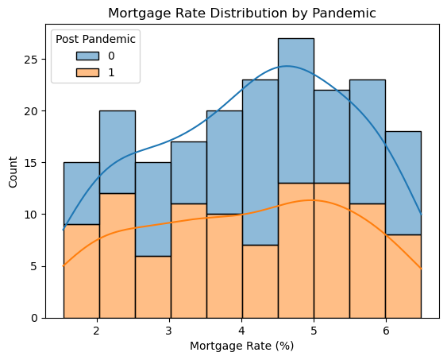

```python
sns.histplot(df, x='Mortgage Rate (%)', binwidth=0.5, kde=True, hue="Post Pandemic", multiple="stack")
# creates a similar histogram but with a hue based on pre or post pandemic
plt.title("Mortgage Rate Distribution by Pandemic")
plt.show()
```

### House Prices vs Rent Prices

Next, I wanted to compare house prices versus rent prices, both in their index and in their affordability. Scatter plots with lines of best fit were used to determine if there was a correlation between the two. Looking at the scatter plot for the indexes themselves, there is not a strong correlation between the two at all. Their line of best fit is pretty flat. However, if we look at rent versus house price affordability, there is a pretty strong correlation between the two. This could be attributed to an outside variable influencing both rent and house prices but it could also be a result of the rent affordability variable being calculated using the price affordability variable.

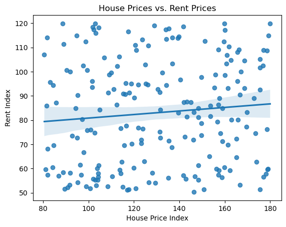

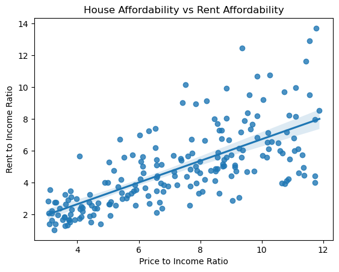

```python
hpivsri = sns.regplot(x="House Price Index", y="Rent Index", data=df) # scatter plot with line of reg. for index
plt.title("House Prices vs. Rent Prices")
plt.show()
hpivsri = sns.regplot(x="Price to Income Ratio", y="Rent to Income Ratio", data=df) # scatter plot with line of reg. for affordability
plt.title("House Affordability vs Rent Affordability")
plt.show()
```

### Affordability Over Time

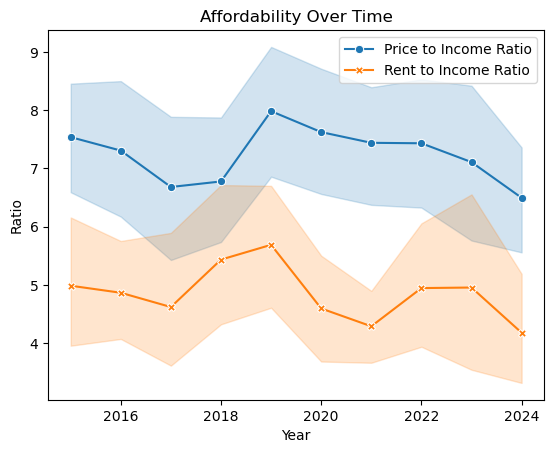

```python
df_afford = pd.melt(df, id_vars = ['Year'], value_vars = ['Price to Income Ratio', 'Rent to Income Ratio'] )
# to merge the two types of affordability onto one graph, the melt() function is used
sns.lineplot(data=df_afford, x='Year', y='value', hue='variable', style='variable', markers=True, dashes=False)
plt.title("Affordability Over Time")
plt.ylabel("Ratio")
plt.legend(title="") # removes the title from the legend to give more room for the information
plt.show()
```

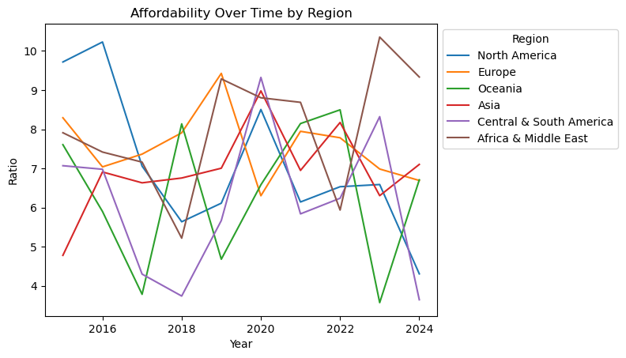

```python
aotbyr = sns.lineplot(df, x="Year", y="Price to Income Ratio", hue="Region", errorbar=None)
# mean price to income ratio by region over time without confidence intervals to increase visual clarity
sns.move_legend(aotbyr, "upper left", bbox_to_anchor=(1, 1)) # moves the legend off of the graph so it doesn't cover anything
plt.title("Affordability Over Time by Region")
plt.ylabel("Ratio")
plt.show()
```

### Geo Map

Next, we're going to use a geographic map to plot the average house price index by country. To start, we need to add some country codes to the data frame to make it useable. I created a new copy of the original data frame specifically for this purpose. It assigns the correct country code to each data line. Then, I ploted this information on a geographic map. The first is simply an average of the house index by country. The next is an animated timeline showing the house index by country by year. And lastly is an animated timeline showing the house price to income ratio by country by year. All three show a more spatial version of previously demonstrated trends and regionally concentrated anomalies.

```python
df_codes = df.copy() # creates a copy of the original data frame

def cou_code(country): # assigns the appropiate country code
    if country == "USA":
        return "USA"
    elif country == "Canada":
        return "CAN"
    elif country == "UK":
        return "GBR"
    elif country == "Germany":
        return "DEU"
    elif country == "France":
        return "FRA"
    elif country == "Italy":
        return "ITA"
    elif country == "Spain":
        return "ESP"
    elif country == "Australia":
        return "AUS"
    elif country == "India":
        return "IND"
    elif country == "China":
        return "CHN"
    elif country == "Japan":
        return "JPN"
    elif country == "Brazil":
        return "BRA"
    elif country == "South Korea":
        return "KOR"
    elif country == "Mexico":
        return "MEX"
    elif country == "South Africa":
        return "ZAF"
    elif country == "Russia":
        return "RUS"
    elif country == "Netherlands":
        return "NLD"
    elif country == "Sweden":
        return "SWE"
    elif country == "Switzerland":
        return "CHE"
    elif country == "UAE":
        return "ARE"
df_codes["Codes"] = df_codes["Country"].apply(cou_code)


df_codes_agg = df_codes.groupby("Codes").agg({
    "House Price Index" : "mean",
    "Rent Index" : "mean",
    "Price to Income Ratio" : "mean",
    "Rent to Income Ratio" : "mean"}).reset_index() # aggregates the information for later use
```

```python
avg_price_map = px.choropleth(df_codes_agg,
                                  locations = "Codes",
                                  color = "House Price Index",
                                scope = "world") # plots the averaage house price index on the map

avg_price_map.show()
```

[interactive chart not shown]

```python
price_map = px.choropleth(df_codes,
                                  animation_frame = "Year",
                                  locations = "Codes",
                                  color = "House Price Index",
                                scope = "world") # animates the house price index year by year

price_map.show()
```

[interactive chart not shown]

```python
price_map = px.choropleth(df_codes,
                                  animation_frame = "Year",
                                  locations = "Codes",
                                  color = "Price to Income Ratio",
                                scope = "world") # animates the house affordability year by year

price_map.show()
```

[interactive chart not shown]